# Logistic Regression

Softanbees Technologies Pvt. Ltd.

8/17/2020

# Introduction

Logistic Regression is a classification algorithm used to assign observations to a discrete set classes. Unlike linear regression which outputs continuous number values, logistic regression transform its output using the logistic sigmoid function to return a probability value which can then be mapped to two or more discrete classes.

# The Theories behind logistic regression

## What is Wrong with Linear Regression for Classification?

When the response variable has only 2 possible values, it is desirable to have a model that predicts the value either as 0 or 1 or as a probability score that ranges between 0 and 1.

Linear regression does not have that capability. Because if you use linear regression to model a binary response varibalbe, the resulting model may not restrict the predicted Y values within 0 and 1.

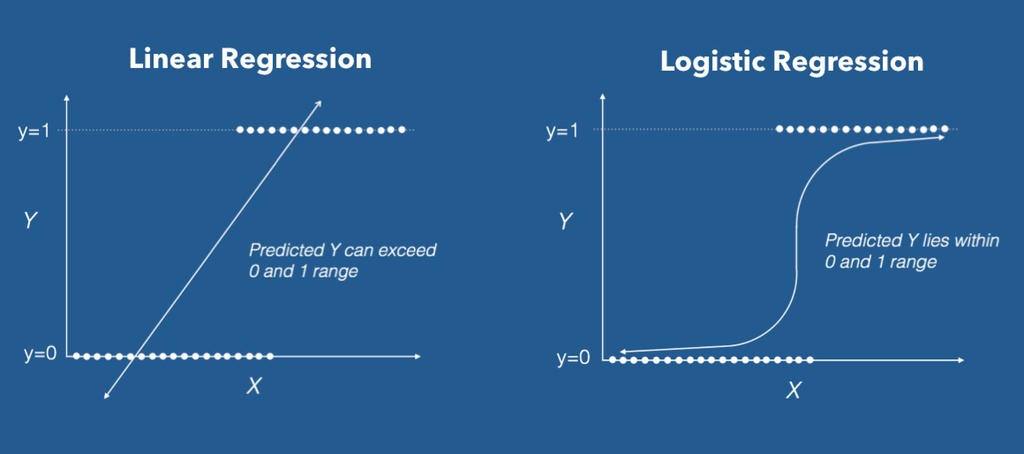

linear vs logistic

This is where logistic regression comes into play. In logistic regression you get a probability score that reflects the probability of the occurence of the event.

An event in this case is each row of the training dataset. It could be something like classifying if a given email is spam, or mass of cell is malignant or a user will buy a product and so on.

## Logistic function and Theories

### Estimated Regression Equation

The natuaral logarithm of the odds ratio is equivalent to a linear function of the independent variables. The antilog of the logit function allows us to find the estimated regression equation.

$$logit(p) = ln\frac{p}{1-p} = \beta_0 + \beta_1x_1$$

This the logit function and antilog is:

$$\frac{p}{1-p} = e^{\beta_0 + \beta_1x_1}$$
$$p = e^{\beta_0 + \beta_1x_1} (1-p)$$
and after derivation we will find the estimated regression equation, which is:

$$\hat{p} = \frac{e^{\beta_0 + \beta_1x_1}}{1 + e^{\beta_0 + \beta_1x_1}}$$
here $\hat{p}$ = predicted output $\b_0$ = bias or intercept term $\b_1$ = the coefficient for the single input value($\x_1$) . Each column in your input data has an associated b coefficient (a constant real value) that must be learned from your training data.

Now we have some confusion about logit? then let’s clear it up.

### What is logit?

In logistic regression we do not know p like we do in Binomial (Bernoulli) distribution problems. THe goal of logistic regression is to estimate p for a linear combination of independent variables. Estimate of p is $\hat{p}$, p hat.

To tie together our linear combination of variables and in essence the Bernoulli distribution we need a function that links them together, or maps the linear combination of variables that could result in any value onto the Bernoulli probability distribution with a domain from 0 to 1. The natural log of the odds ratio, the logit, is that link function.

ln(odds) we can rewrite it to,
$$ln\frac{p}{1-p}$$
is the logit(p) or ln(odds)

**Inverse Logit** Here from the logit function we get the probabilities in the x axis. But we want our probabilities in the y axis. SO that we will inverse the logit function.

$$logit(p) = ln\frac{p}{p-1}$$
where p is between 0 and 1 in the x axis.

now after doing the inversion:

$$logit^{-1}(\alpha) = \frac{e^{\alpha}}{1+e^{\alpha}}$$

here $\alpha$ = linear combination of variables and their coefficients.

The inverse logit will return the probability of being a “1” or in the “event occurs” group.

The inverse logit sometimes called the mean function.

$$\mu_{y|x} = \frac{e^{\alpha}}{1+e^{\alpha}}$$

**Note about coefficients** The regression coefficients for logistic regression are calculated using maximum likelihood estimation or MLE. https://www.youtube.com/watch?v=XepXtl9YKwc this is link for learning about maximum likelihood.

# Practical Implementation

## Details about the dataset

The Framingham Heart Study is a long term prospective study of the etiology of cardiovascular disease among a population of free living subjects in the community of Framingham, Massachusetts. The Framingham Heart Study was a landmark study in epidemiology in that it was the first prospective study of cardiovascular disease and identified the concept of risk factors and their joint effects FHS Longitudinal Data Document.

The dataset is a rather small subset of possible FHS dataset, having 4240 observations and 16 variables. The variables are as follows:

- sex: the gender of the observations. the variable is a binary named “male” in the dataset. 1 is male and 0 female
- age: Age at the time of medical examination in years
- education: A categorical variable of the participants, with the levels: Some high school(1), high School/GED(2), some college/vocational school(3), college(4)
- currentSmoker: Current cigarette smoking at the time of examination.
- cigsPerDay: Number of cigarettes smoked each day
- BPmeds: Use of Anti-hypertensive medication at exam
- prevalentStroke: Prevalent Stroke (0 = free of disease)
- prevalentHyp: Prevalent Hypertensive. Subject was defined as hypertensive if treated
- diabetes: Diabetic according to criteria of first exam treated
- totChol: Total cholesterol (mg/dL)
- sysBP: Systolic Blood Pressure (mmHg)
- diaBP: Diastolic blood pressure (mmHg)
- BMI: Body Mass Index, weight (kg)/height (m)^2
- heartRate: Heart rate (beats/minute)
- glucose: Blood glucose level (mg/dL)
- And finally the response variable : + TenYearCHD : The 10 year risk of coronary heart disease(CHD).

## Insert and explore the datasets

```r
heart <- read_csv("/Users/tanvir/Desktop/softanbees_files/Logistic\ Regression/framingham.csv")
heart %>%
  head() %>%
  kable() %>%
  kable_styling(bootstrap_options = c("striped", "hover", "condensed", "responsive")) %>%
  scroll_box(width = "800px", height = "200px")
```

| male | age | education | currentSmoker | cigsPerDay | BPMeds | prevalentStroke | prevalentHyp | diabetes | totChol | sysBP | diaBP | BMI | heartRate | glucose | TenYearCHD |
| --- | --- | --- | --- | --- | --- | --- | --- | --- | --- | --- | --- | --- | --- | --- | --- |
| 1 | 39 | 4 | 0 | 0 | 0 | 0 | 0 | 0 | 195 | 106.0 | 70 | 26.97 | 80 | 77 | 0 |
| 0 | 46 | 2 | 0 | 0 | 0 | 0 | 0 | 0 | 250 | 121.0 | 81 | 28.73 | 95 | 76 | 0 |
| 1 | 48 | 1 | 1 | 20 | 0 | 0 | 0 | 0 | 245 | 127.5 | 80 | 25.34 | 75 | 70 | 0 |
| 0 | 61 | 3 | 1 | 30 | 0 | 0 | 1 | 0 | 225 | 150.0 | 95 | 28.58 | 65 | 103 | 1 |
| 0 | 46 | 3 | 1 | 23 | 0 | 0 | 0 | 0 | 285 | 130.0 | 84 | 23.10 | 85 | 85 | 0 |
| 0 | 43 | 2 | 0 | 0 | 0 | 0 | 1 | 0 | 228 | 180.0 | 110 | 30.30 | 77 | 99 | 0 |

```r
heart$TenYearCHD = as.factor(heart$TenYearCHD)
str(heart)
```

```
## tibble [4,240 × 16] (S3: spec_tbl_df/tbl_df/tbl/data.frame)
##  $ male           : num [1:4240] 1 0 1 0 0 0 0 0 1 1 ...
##  $ age            : num [1:4240] 39 46 48 61 46 43 63 45 52 43 ...
##  $ education      : num [1:4240] 4 2 1 3 3 2 1 2 1 1 ...
##  $ currentSmoker  : num [1:4240] 0 0 1 1 1 0 0 1 0 1 ...
##  $ cigsPerDay     : num [1:4240] 0 0 20 30 23 0 0 20 0 30 ...
##  $ BPMeds         : num [1:4240] 0 0 0 0 0 0 0 0 0 0 ...
##  $ prevalentStroke: num [1:4240] 0 0 0 0 0 0 0 0 0 0 ...
##  $ prevalentHyp   : num [1:4240] 0 0 0 1 0 1 0 0 1 1 ...
##  $ diabetes       : num [1:4240] 0 0 0 0 0 0 0 0 0 0 ...
##  $ totChol        : num [1:4240] 195 250 245 225 285 228 205 313 260 225 ...
##  $ sysBP          : num [1:4240] 106 121 128 150 130 ...
##  $ diaBP          : num [1:4240] 70 81 80 95 84 110 71 71 89 107 ...
##  $ BMI            : num [1:4240] 27 28.7 25.3 28.6 23.1 ...
##  $ heartRate      : num [1:4240] 80 95 75 65 85 77 60 79 76 93 ...
##  $ glucose        : num [1:4240] 77 76 70 103 85 99 85 78 79 88 ...
##  $ TenYearCHD     : Factor w/ 2 levels "0","1": 1 1 1 2 1 1 2 1 1 1 ...
##  - attr(*, "spec")=
##   .. cols(
##   ..   male = col_double(),
##   ..   age = col_double(),
##   ..   education = col_double(),
##   ..   currentSmoker = col_double(),
##   ..   cigsPerDay = col_double(),
##   ..   BPMeds = col_double(),
##   ..   prevalentStroke = col_double(),
##   ..   prevalentHyp = col_double(),
##   ..   diabetes = col_double(),
##   ..   totChol = col_double(),
##   ..   sysBP = col_double(),
##   ..   diaBP = col_double(),
##   ..   BMI = col_double(),
##   ..   heartRate = col_double(),
##   ..   glucose = col_double(),
##   ..   TenYearCHD = col_double()
##   .. )
```

Risk of having coronary heart disease (CHD) according to consumption of ciggarete per day

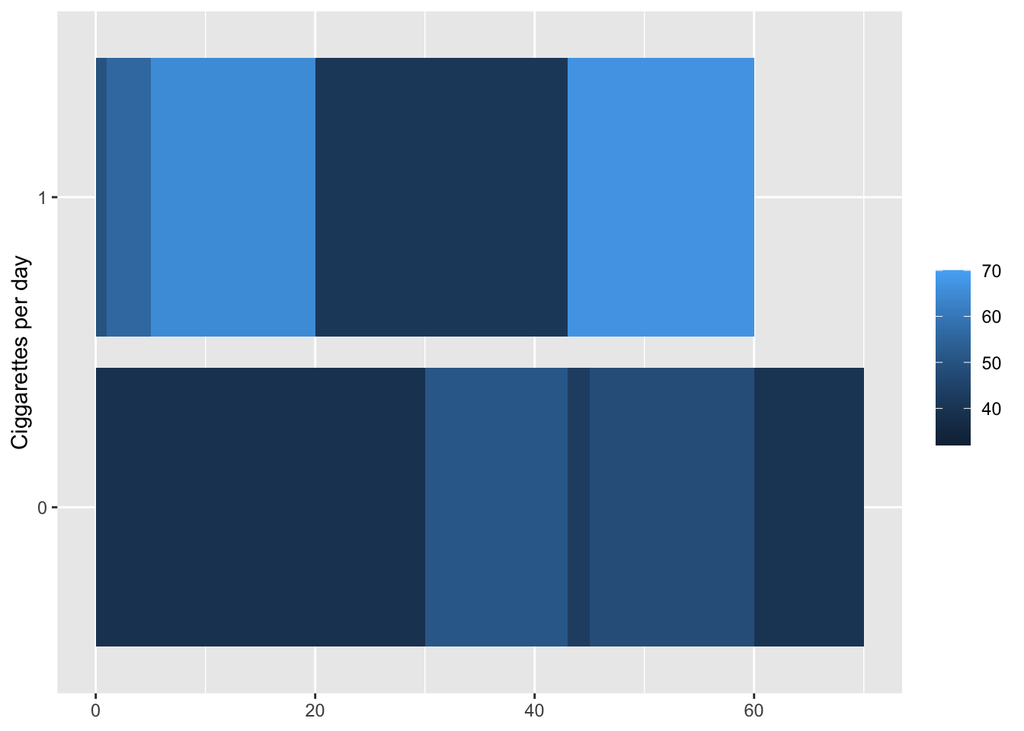

```r
heart %>%
  group_by(TenYearCHD, cigsPerDay) %>%
  ggplot(aes(cigsPerDay, TenYearCHD, fill = age)) +
  geom_col(position = "dodge")+
  labs(
    x = NULL,
    y = "Ciggarettes per day",
    fill = NULL
  )
```

```r
skim(heart)
```

Data summary

| Name | heart |
| --- | --- |
| Number of rows | 4240 |
| Number of columns | 16 |
| _______________________ |  |
| Column type frequency: |  |
| factor | 1 |
| numeric | 15 |
| ________________________ |  |
| Group variables | None |

**Variable type: factor**

| skim_variable | n_missing | complete_rate | ordered | n_unique | top_counts |
| --- | --- | --- | --- | --- | --- |
| TenYearCHD | 0 | 1 | FALSE | 2 | 0: 3596, 1: 644 |

**Variable type: numeric**

| skim_variable | n_missing | complete_rate | mean | sd | p0 | p25 | p50 | p75 | p100 | hist |
| --- | --- | --- | --- | --- | --- | --- | --- | --- | --- | --- |
| male | 0 | 1.00 | 0.43 | 0.50 | 0.00 | 0.00 | 0.0 | 1.00 | 1.0 | ▇▁▁▁▆ |
| age | 0 | 1.00 | 49.58 | 8.57 | 32.00 | 42.00 | 49.0 | 56.00 | 70.0 | ▃▇▆▆▂ |
| education | 105 | 0.98 | 1.98 | 1.02 | 1.00 | 1.00 | 2.0 | 3.00 | 4.0 | ▇▆▁▃▂ |
| currentSmoker | 0 | 1.00 | 0.49 | 0.50 | 0.00 | 0.00 | 0.0 | 1.00 | 1.0 | ▇▁▁▁▇ |
| cigsPerDay | 29 | 0.99 | 9.01 | 11.92 | 0.00 | 0.00 | 0.0 | 20.00 | 70.0 | ▇▃▁▁▁ |
| BPMeds | 53 | 0.99 | 0.03 | 0.17 | 0.00 | 0.00 | 0.0 | 0.00 | 1.0 | ▇▁▁▁▁ |
| prevalentStroke | 0 | 1.00 | 0.01 | 0.08 | 0.00 | 0.00 | 0.0 | 0.00 | 1.0 | ▇▁▁▁▁ |
| prevalentHyp | 0 | 1.00 | 0.31 | 0.46 | 0.00 | 0.00 | 0.0 | 1.00 | 1.0 | ▇▁▁▁▃ |
| diabetes | 0 | 1.00 | 0.03 | 0.16 | 0.00 | 0.00 | 0.0 | 0.00 | 1.0 | ▇▁▁▁▁ |
| totChol | 50 | 0.99 | 236.70 | 44.59 | 107.00 | 206.00 | 234.0 | 263.00 | 696.0 | ▆▇▁▁▁ |
| sysBP | 0 | 1.00 | 132.35 | 22.03 | 83.50 | 117.00 | 128.0 | 144.00 | 295.0 | ▇▇▁▁▁ |
| diaBP | 0 | 1.00 | 82.90 | 11.91 | 48.00 | 75.00 | 82.0 | 90.00 | 142.5 | ▁▇▅▁▁ |
| BMI | 19 | 1.00 | 25.80 | 4.08 | 15.54 | 23.07 | 25.4 | 28.04 | 56.8 | ▅▇▁▁▁ |
| heartRate | 1 | 1.00 | 75.88 | 12.03 | 44.00 | 68.00 | 75.0 | 83.00 | 143.0 | ▂▇▃▁▁ |
| glucose | 388 | 0.91 | 81.96 | 23.95 | 40.00 | 71.00 | 78.0 | 87.00 | 394.0 | ▇▁▁▁▁ |

So, we have explored our dataset. Now we will build model with it.

## creating model

```r
set.seed(1234)
heart_split <- initial_split(heart,strata = TenYearCHD)

heart_train <- training(heart_split)
heart_test <- testing(heart_split)

count(heart_train)
```

```
## # A tibble: 1 x 1
##       n
##   <int>
## 1  3180
```

```r
count(heart_test)
```

```
## # A tibble: 1 x 1
##       n
##   <int>
## 1  1060
```

So, in training dataset there is 3180 number of data and testing there are 1060.

We will use recipe() to build a set of steps for data preprocessing and feature engineering.

```r
heart_rec <- recipe(TenYearCHD ~ ., data = heart_train) %>%
  step_downsample(TenYearCHD) %>%
  step_dummy(all_nominal(), -all_outcomes()) %>%
  step_zv(all_numeric()) %>%
  step_normalize(all_numeric()) %>%
  prep()
test_heart <- bake(heart_rec, new_data = heart_test)

heart_rec
```

```
## Data Recipe
##
## Inputs:
##
##       role #variables
##    outcome          1
##  predictor         15
##
## Training data contained 3180 data points and 438 incomplete rows.
##
## Operations:
##
## Down-sampling based on TenYearCHD [trained]
## Dummy variables were *not* created since no columns were selected. [trained]
## Zero variance filter removed no terms [trained]
## Centering and scaling for male, age, education, currentSmoker, ... [trained]
```

Now we will create the glm model

```r
glm.fit <-
  logistic_reg(mode = "classification") %>%
  set_engine(engine = "glm") %>%
  fit(TenYearCHD ~ ., data = heart_train)

tidy(glm.fit)
```

```
## # A tibble: 16 x 5
##    term            estimate std.error statistic  p.value
##    <chr>              <dbl>     <dbl>     <dbl>    <dbl>
##  1 (Intercept)     -8.67      0.837     -10.4   3.65e-25
##  2 male             0.643     0.127       5.06  4.21e- 7
##  3 age              0.0564    0.00770     7.32  2.42e-13
##  4 education       -0.0513    0.0571     -0.898 3.69e- 1
##  5 currentSmoker   -0.172     0.187      -0.920 3.58e- 1
##  6 cigsPerDay       0.0246    0.00739     3.33  8.68e- 4
##  7 BPMeds           0.317     0.267       1.19  2.35e- 1
##  8 prevalentStroke  0.306     0.595       0.514 6.07e- 1
##  9 prevalentHyp     0.254     0.160       1.59  1.12e- 1
## 10 diabetes        -0.0481    0.371      -0.130 8.97e- 1
## 11 totChol          0.00332   0.00134     2.47  1.34e- 2
## 12 sysBP            0.0152    0.00445     3.43  6.13e- 4
## 13 diaBP           -0.00171   0.00744    -0.229 8.18e- 1
## 14 BMI              0.00992   0.0148      0.672 5.01e- 1
## 15 heartRate       -0.00184   0.00482    -0.382 7.02e- 1
## 16 glucose          0.00834   0.00254     3.28  1.03e- 3
```

Now we will see without tidymodels

```r
heartlog = glm(TenYearCHD~., data = heart_train, family = binomial)
heartlog
```

```
##
## Call:  glm(formula = TenYearCHD ~ ., family = binomial, data = heart_train)
##
## Coefficients:
##     (Intercept)             male              age        education
##       -8.671964         0.643217         0.056356        -0.051263
##   currentSmoker       cigsPerDay           BPMeds  prevalentStroke
##       -0.171709         0.024605         0.317183         0.305842
##    prevalentHyp         diabetes          totChol            sysBP
##        0.254423        -0.048112         0.003321         0.015237
##           diaBP              BMI        heartRate          glucose
##       -0.001707         0.009916        -0.001842         0.008341
##
## Degrees of Freedom: 2741 Total (i.e. Null);  2726 Residual
##   (438 observations deleted due to missingness)
## Null Deviance:       2348
## Residual Deviance: 2054  AIC: 2086
```

Now predicting the the heart disease

```r
pred_glm_fit<- predict(glm.fit, new_data = heart_train)

pred_glm_fit_test<- predict(glm.fit, new_data = heart_test)

prob_glm_fit_test <- predict(glm.fit, new_data = heart_test, type = "prob")
```

## Evaluating model performance

```r
metrics(bind_cols(heart_test, pred_glm_fit_test), truth = TenYearCHD, estimate = .pred_class)
```

```
## # A tibble: 2 x 3
##   .metric  .estimator .estimate
##   <chr>    <chr>          <dbl>
## 1 accuracy binary        0.853
## 2 kap      binary        0.0533
```

By default yardstick package yardstick::metrics returns accuracy and kappa. The accuracy of our model is 85.25%

We also have access to other metrics with specific functions such as yardstick::spec for specificity, yardstick::precision, yardstick::recall… These metrics can be combined to be estimated together with yardstick::metric_set.

```r
multimetric <- metric_set(accuracy, bal_accuracy, sens, yardstick::spec, precision, recall, ppv, npv)
multimetric(bind_cols(heart_test, pred_glm_fit_test), truth = TenYearCHD, estimate = .pred_class)
```

```
## # A tibble: 8 x 3
##   .metric      .estimator .estimate
##   <chr>        <chr>          <dbl>
## 1 accuracy     binary        0.853
## 2 bal_accuracy binary        0.516
## 3 sens         binary        0.996
## 4 spec         binary        0.0365
## 5 precision    binary        0.855
## 6 recall       binary        0.996
## 7 ppv          binary        0.855
## 8 npv          binary        0.625
```

Computing the area under the ROC and then plot it.

```r
roc_auc(bind_cols(heart_test, prob_glm_fit_test), truth = TenYearCHD, .pred_1)
```

```
## # A tibble: 1 x 3
##   .metric .estimator .estimate
##   <chr>   <chr>          <dbl>
## 1 roc_auc binary         0.287
```

visualization

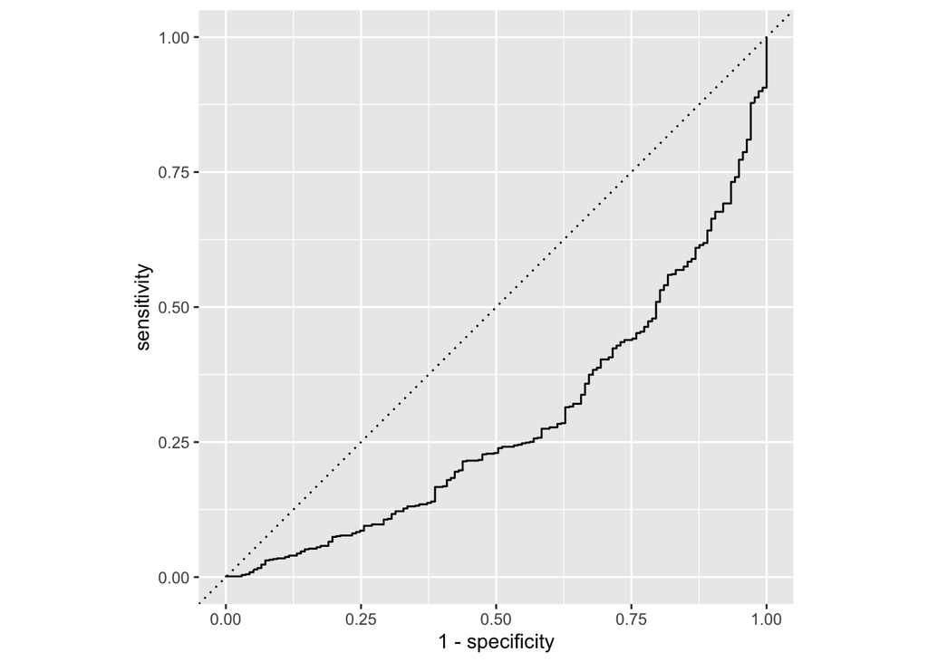

```r
roc_data <- roc_curve(bind_cols(heart_test, prob_glm_fit_test), truth = TenYearCHD, .pred_1)
roc_data %>%
  ggplot(aes(x = 1 - specificity, y = sensitivity)) +
  geom_path() +
  geom_abline(lty = 3) +
  coord_equal()
```

And that’s how we make model in logistic regression.